# Midterm_nba_report

四月 18, 2025

# Introduction

Scripts are located in `Code/`, and all outputs are written to `Output/`.

# Data Analysis

## Coder 1: Data Preparation & Player Summary

### 1. Data Cleaning Process

The source file was downloaded and imported into Excel. A comma‑delimited export produced **NBA.xlsx**, which was then saved as **nba_2025-03-07.csv**. Static cells requiring no computation were verified against common‑sense values and assumed correct. Computed columns exhibited missing values (blank or NA) due to zero denominators in original formulas. We removed the `reward` column and the `League Average` row, then recomputed percentage‑based columns (`3P%`, `2P%`, `eFG%`, `FT%`) rounding to three decimal places. The final cleaned dataset was saved as **nba_clean.csv** in the `Output/` folder.

### 2. Read and Clean NBA Data

```
## # A tibble: 5 × 30
##      Rk Player   Age Team  Pos       G    GS    MP    FG   FGA `FG%`  `3P` `3PA`
##   <dbl> <chr>  <dbl> <chr> <chr> <dbl> <dbl> <dbl> <dbl> <dbl> <dbl> <dbl> <dbl>
## 1     1 Mikal…    28 NYK   SF       62    62  2344   6.8  13.9 0.489   2.1   5.9
## 2     2 Josh …    29 NYK   SG       59    59  2230   5.3   9.7 0.546   1     3.1
## 3     3 Antho…    23 MIN   SG       61    61  2227   8.9  20.3 0.438   4.1  10
## 4     4 Jalen…    28 NYK   PG       61    61  2162   9.3  18.9 0.492   2.3   6.1
## 5     5 Jayso…    26 BOS   PF       59    59  2147   9.1  20   0.455   3.5  10
## # ℹ 17 more variables: `3P%` <dbl>, `2P` <dbl>, `2PA` <dbl>, `2P%` <dbl>,
## #   `eFG%` <dbl>, FT <dbl>, FTA <dbl>, `FT%` <dbl>, ORB <dbl>, DRB <dbl>,
## #   TRB <dbl>, AST <dbl>, STL <dbl>, BLK <dbl>, TOV <dbl>, PF <dbl>, PTS <dbl>
```

### 3. Descriptive Statistics

Descriptive Statistics for Key Metrics

| MeanPoints | MedianPoints | MaxPoints | MeanRebounds | MedianRebounds | MaxRebounds | MeanAssists | MedianAssists | MaxAssists | MeaneFGPct | MeanFTPercent | MeanMinutes |
| --- | --- | --- | --- | --- | --- | --- | --- | --- | --- | --- | --- |
| 14.77602 | 14.4 | 45 | 6.839474 | 6 | 36 | 3.650146 | 3.2 | 21 | 0.5138216 | 0.6926535 | 726.9327 |

### 4. Summary Tables by Group

Summary by Team

| Team | Count | AvgPoints | AvgRebounds | AvgAssists | AvgeFGPct | AvgMP |
| --- | --- | --- | --- | --- | --- | --- |
| 2TM | 65 | 14.44154 | 6.970769 | 3.861538 | 0.5168000 | 704.7846 |
| 3TM | 1 | 17.40000 | 3.400000 | 6.900000 | 0.4970000 | 1595.0000 |
| ATL | 20 | 16.82500 | 6.390000 | 3.390000 | 0.5737000 | 760.9500 |
| BOS | 18 | 13.15000 | 7.277778 | 2.872222 | 0.5024444 | 846.8889 |
| BRK | 22 | 15.60909 | 5.836364 | 3.518182 | 0.5083182 | 679.8636 |
| CHI | 22 | 15.19545 | 7.068182 | 4.281818 | 0.5046818 | 690.6818 |
| CHO | 25 | 13.96000 | 6.952000 | 3.808000 | 0.4884800 | 588.6000 |
| CLE | 20 | 16.46500 | 7.190000 | 3.605000 | 0.5679500 | 745.2000 |
| DAL | 23 | 16.57826 | 7.521739 | 3.665217 | 0.5710000 | 659.6087 |
| DEN | 17 | 13.79412 | 7.200000 | 3.417647 | 0.5235294 | 881.1765 |
| DET | 19 | 15.00526 | 5.794737 | 3.847368 | 0.4916316 | 801.0526 |
| GSW | 22 | 15.88636 | 7.163636 | 4.677273 | 0.5328636 | 688.4091 |
| HOU | 17 | 16.07647 | 7.517647 | 2.847059 | 0.5237647 | 893.8235 |
| IND | 22 | 15.13636 | 7.181818 | 3.690909 | 0.4749091 | 668.9091 |
| LAC | 22 | 15.71364 | 6.522727 | 3.372727 | 0.5385000 | 679.7273 |
| LAL | 24 | 13.31667 | 6.029167 | 3.266667 | 0.5300417 | 612.0833 |
| MEM | 21 | 15.16667 | 6.533333 | 3.623810 | 0.5019048 | 709.7143 |
| MIA | 20 | 14.09500 | 6.605000 | 3.585000 | 0.5235000 | 743.2500 |
| MIL | 22 | 14.49545 | 6.931818 | 3.650000 | 0.5307727 | 666.7273 |
| MIN | 19 | 13.10526 | 6.968421 | 4.189474 | 0.4614211 | 812.2632 |
| NOP | 22 | 15.05455 | 6.900000 | 4.000000 | 0.5024091 | 690.7273 |
| NYK | 17 | 13.67647 | 6.323529 | 3.352941 | 0.5381765 | 884.1765 |
| OKC | 19 | 15.94737 | 7.600000 | 3.084211 | 0.5308421 | 784.4737 |
| ORL | 17 | 14.15882 | 6.076471 | 3.905882 | 0.4714118 | 906.3529 |
| PHI | 24 | 14.82500 | 6.795833 | 3.250000 | 0.5004583 | 624.0833 |
| PHO | 19 | 14.50526 | 6.510526 | 3.226316 | 0.5071579 | 789.8421 |
| POR | 18 | 13.88889 | 6.888889 | 2.861111 | 0.4605556 | 842.7222 |
| SAC | 23 | 14.04348 | 6.917391 | 3.886957 | 0.5105652 | 644.2174 |
| SAS | 21 | 14.45238 | 6.842857 | 4.780952 | 0.5170952 | 688.2381 |
| TOR | 21 | 13.79048 | 6.514286 | 3.728571 | 0.4905714 | 714.4762 |
| UTA | 20 | 14.62000 | 6.935000 | 3.220000 | 0.5334000 | 749.0000 |
| WAS | 22 | 15.17727 | 7.909091 | 3.581818 | 0.4867273 | 667.8636 |

Summary by Position

| Pos | Count | AvgPoints | AvgRebounds | AvgAssists | AvgeFGPct | AvgMP |
| --- | --- | --- | --- | --- | --- | --- |
| C | 129 | 14.62636 | 10.972868 | 2.768992 | 0.5616589 | 683.8992 |
| PF | 122 | 15.19754 | 7.907377 | 2.823771 | 0.5246230 | 738.4918 |
| PG | 131 | 15.04275 | 4.548092 | 6.228244 | 0.4971527 | 758.2595 |
| SF | 121 | 14.40992 | 6.451240 | 2.743802 | 0.4813554 | 725.5289 |
| SG | 181 | 14.65028 | 5.091713 | 3.575138 | 0.5062155 | 728.0773 |

### 5. Player Ranking Tables

Top 10 Players by Points

| Player | Team | Pos | PTS |
| --- | --- | --- | --- |
| Alondes Williams | DET | SG | 45.0 |
| James Wiseman | IND | C | 43.2 |
| Alex Reese | OKC | PF | 36.0 |
| Shai Gilgeous-Alexander | OKC | PG | 34.5 |
| Giannis Antetokounmpo | MIL | PF | 32.7 |
| Zion Williamson | NOP | PF | 31.2 |
| Anthony Davis | DAL | PF | 30.2 |
| LaMelo Ball | CHO | PG | 29.0 |
| Nikola Jokić | DEN | C | 28.7 |
| Luka Dončić | DAL | PG | 28.4 |

Top 10 Players by Rebounds

| Player | Team | Pos | TRB |
| --- | --- | --- | --- |
| Jaylen Martin | WAS | SF | 36.0 |
| Oscar Tshiebwe | UTA | C | 18.7 |
| Anthony Davis | DAL | PF | 18.6 |
| Alex Reese | OKC | PF | 18.0 |
| Tristen Newton | MIN | SG | 18.0 |
| Miles Norris | BOS | PF | 18.0 |
| Tony Bradley | IND | C | 18.0 |
| Chuma Okeke | PHI | PF | 18.0 |
| Jahmir Young | CHI | PG | 18.0 |
| N’Faly Dante | HOU | C | 17.1 |

Top 10 Players by Assists

| Player | Team | Pos | AST |
| --- | --- | --- | --- |
| Jordan McLaughlin | SAS | PG | 21.0 |
| Jahmir Young | CHI | PG | 18.0 |
| Mac McClung | ORL | SG | 14.4 |
| Elfrid Payton | NOP | PG | 12.0 |
| Jahlil Okafor | IND | C | 12.0 |
| Trae Young | ATL | PG | 11.5 |
| Nikola Jokić | DEN | C | 10.3 |
| Mason Jones | SAC | SG | 10.3 |
| Chris Paul | SAS | PG | 10.0 |
| Ben Simmons | BRK | PG | 10.0 |

Overall Top 10 Players

| Player | Team | Pos | PTS | TRB | AST |
| --- | --- | --- | --- | --- | --- |
| Alondes Williams | DET | SG | 45.0 | 0.0 | 9.0 |
| James Wiseman | IND | C | 43.2 | 7.2 | 0.0 |
| Alex Reese | OKC | PF | 36.0 | 18.0 | 0.0 |
| Shai Gilgeous-Alexander | OKC | PG | 34.5 | 5.4 | 6.5 |
| Giannis Antetokounmpo | MIL | PF | 32.7 | 12.9 | 6.3 |
| Zion Williamson | NOP | PF | 31.2 | 9.4 | 6.5 |
| Anthony Davis | DAL | PF | 30.2 | 18.6 | 8.1 |
| LaMelo Ball | CHO | PG | 29.0 | 5.9 | 7.7 |
| Nikola Jokić | DEN | C | 28.7 | 12.7 | 10.3 |
| Luka Dončić | DAL | PG | 28.4 | 8.4 | 7.9 |

### 6. Visualizations

We created several plots to better understand the structure of the dataset in terms of team composition, position roles, and age distribution.

We first visualize the number of players per team, highlighting which teams have the largest or smallest rosters.

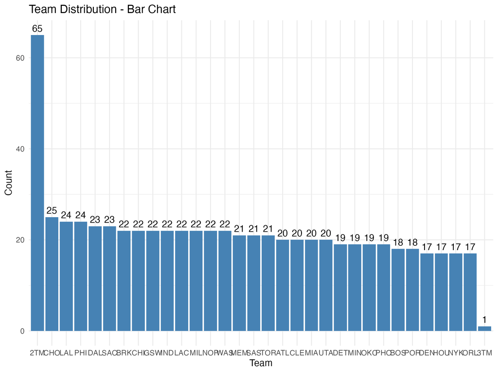

Number of Players by Team

Next, we assess the distribution of players across different positions using a bar chart.

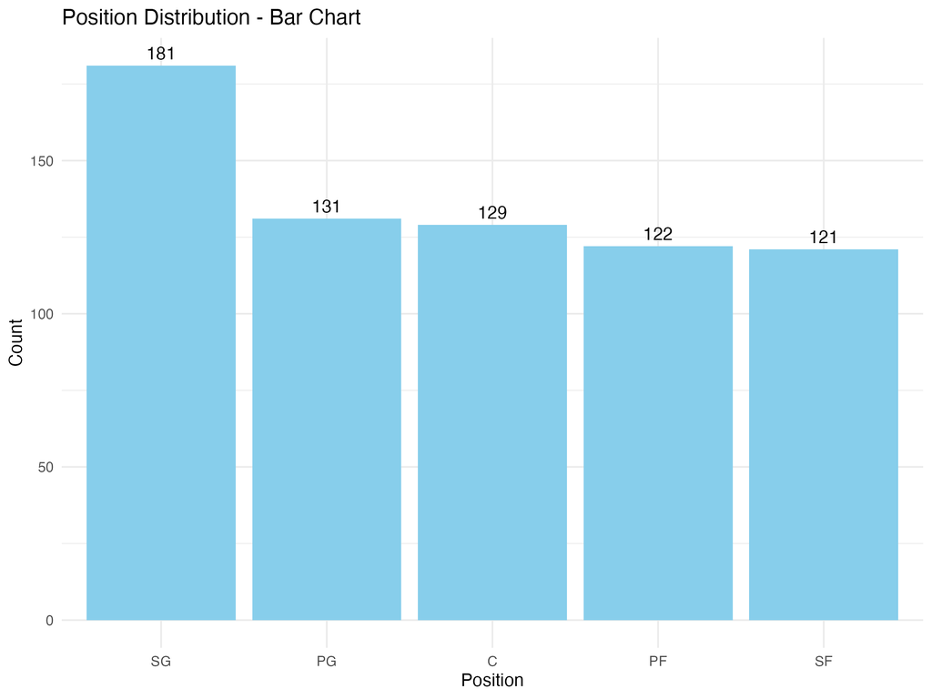

Number of Players by Position

The following pie chart shows the percentage breakdown of players by position, offering a proportional view.

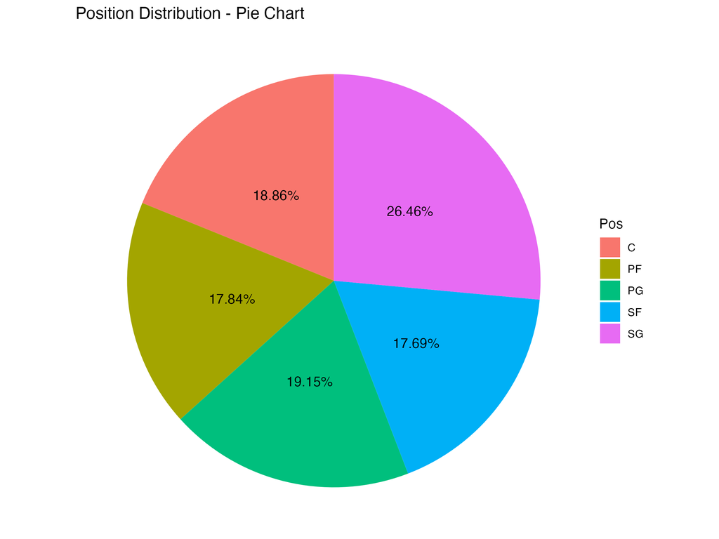

Position Distribution as Percentage

Lastly, we explore the age structure of players using a histogram divided into 10 equal-width intervals.

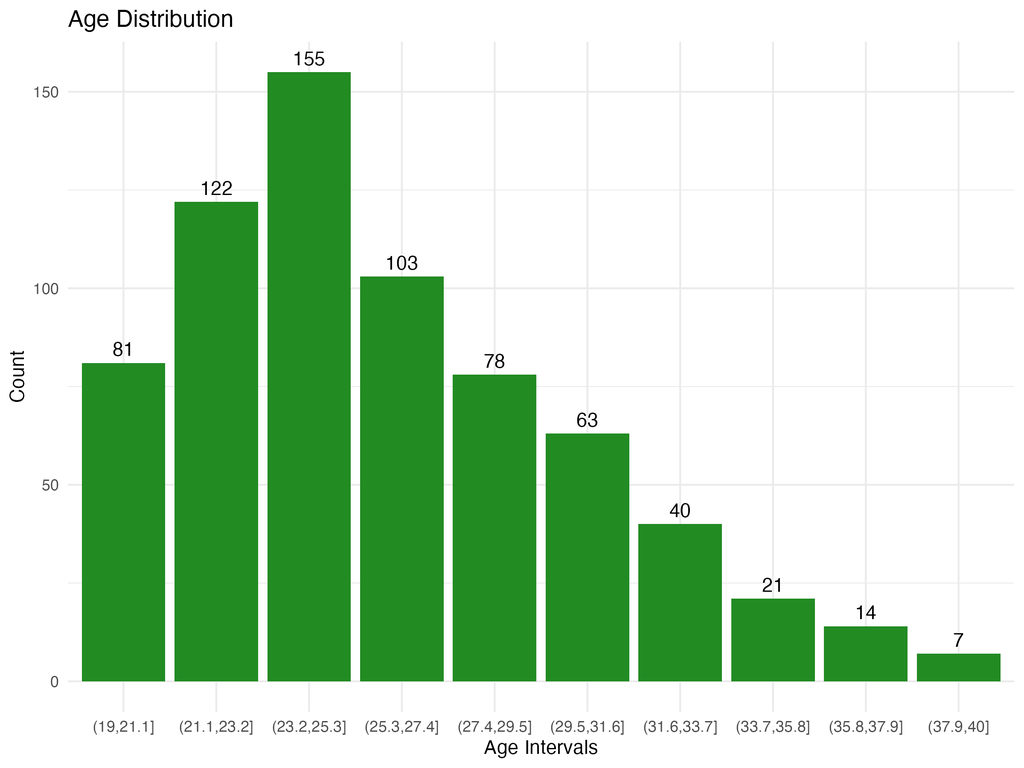

Age Distribution (10 Intervals) with Counts

## Coder 3: Defense and Rebounding Analysis

### 1. Rebounding Analysis by Position

Rebounding is a crucial aspect of basketball that ends opponent possessions and creates second-chance opportunities. We analyzed how different positions contribute to team rebounding efforts.

Rebounding Statistics by Position

| Position | Offensive Rebounds | Defensive Rebounds | Total Rebounds | Number of Players |
| --- | --- | --- | --- | --- |
| C | 3.53 | 7.51 | 11.04 | 93 |
| PF | 2.02 | 5.64 | 7.67 | 87 |
| SF | 1.47 | 4.47 | 5.94 | 78 |
| SG | 1.16 | 3.67 | 4.82 | 122 |
| PG | 0.85 | 3.62 | 4.47 | 91 |

The visualization below shows the breakdown between offensive and defensive rebounds across positions:

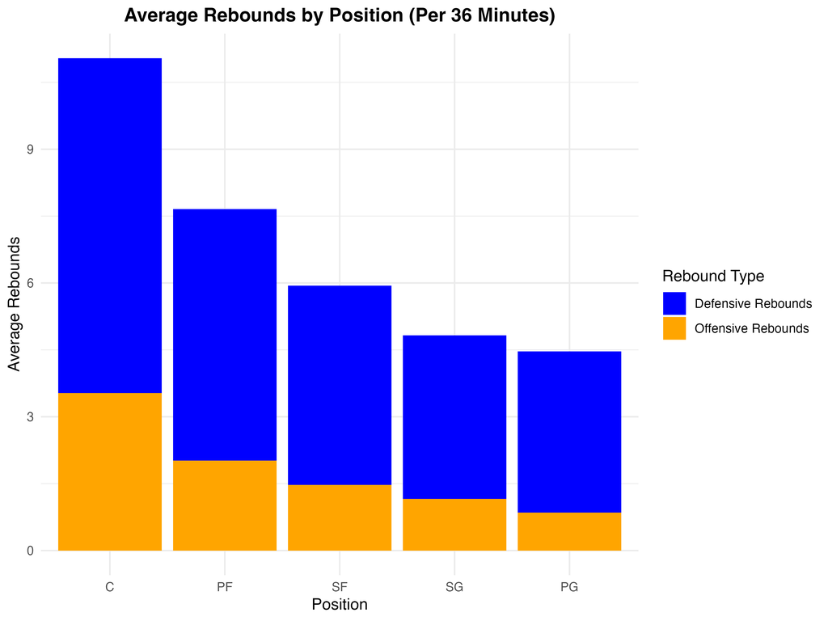

**Key Findings:** - Centers lead in total rebounding, with particular strength in defensive rebounds - Power forwards are second in rebounding contribution - Guards (PG, SG) have the lowest rebounding numbers, as expected given their role and typical positioning

### 2. Defensive Metrics Analysis by Position

We also analyzed key defensive statistics (steals and blocks) to understand how different positions contribute to team defense.

Defensive Statistics by Position

| Position | Steals | Blocks | Number of Players |
| --- | --- | --- | --- |
| C | 1.03 | 1.58 | 93 |
| PF | 1.14 | 0.87 | 87 |
| PG | 1.50 | 0.44 | 91 |
| SF | 1.20 | 0.58 | 78 |
| SG | 1.36 | 0.48 | 122 |

The visualization below compares steals and blocks across positions:

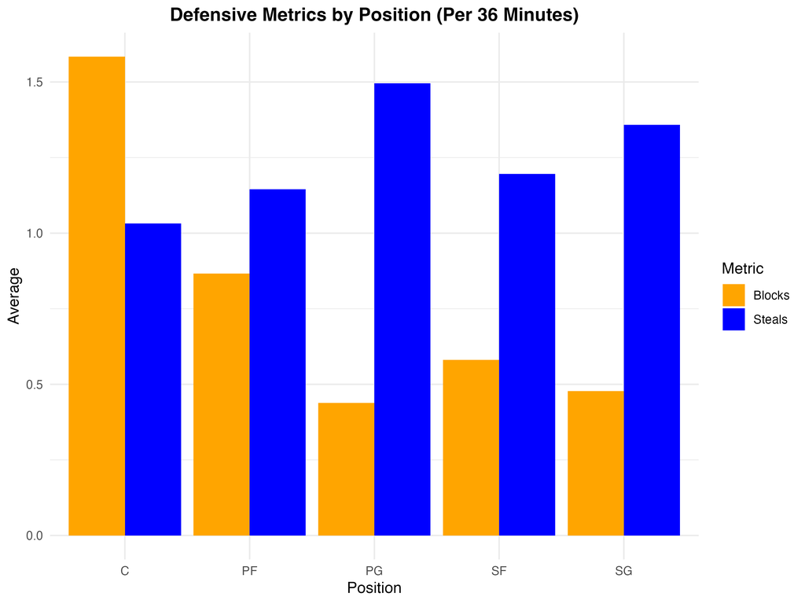

**Key Findings:** - Point guards excel at generating steals but provide minimal shot-blocking - Centers dominate in blocks while contributing fewer steals - Each position shows a distinct defensive profile that aligns with their typical role on the court

### 3. Position Role Analysis

Combined Defensive and Rebounding Metrics by Position

| Pos | Rebounding_Score | Defensive_Score | Total_Score |
| --- | --- | --- | --- |
| C | 6.12 | 1.31 | 3.71 |
| PF | 4.37 | 1.01 | 2.69 |
| SF | 3.42 | 0.89 | 2.15 |
| SG | 2.79 | 0.92 | 1.85 |
| PG | 2.65 | 0.97 | 1.81 |

By combining our defensive and rebounding metrics, we can characterize the overall defensive contribution of each position:

These distinct roles highlight how basketball teams rely on position specialization to create a complete defensive system.

## Coder 4: Age and Experience Analysis

This section investigates the relationship between player age and scoring performance. The metric used is points per 36 minutes (PTS). Visualizations include a density plot, scatter plot, and boxplot grouped by age. The analysis also identifies the peak performance age.

### 1. Density Plot of Age Distribution

The density plot below shows the age distribution of NBA players, highlighting the concentration of players in different age ranges.

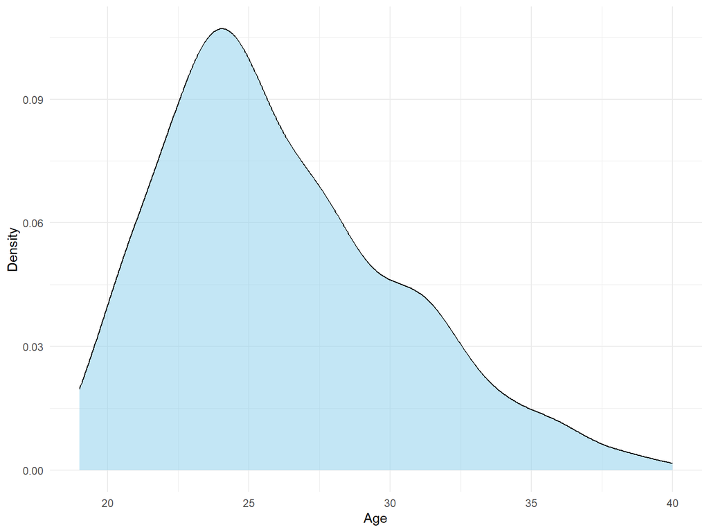

### 2. Age vs. Scoring Performance

The scatter plot with LOESS smoothing demonstrates the relationship between age and scoring efficiency. Points represent individual players, and the blue curve indicates the trend.

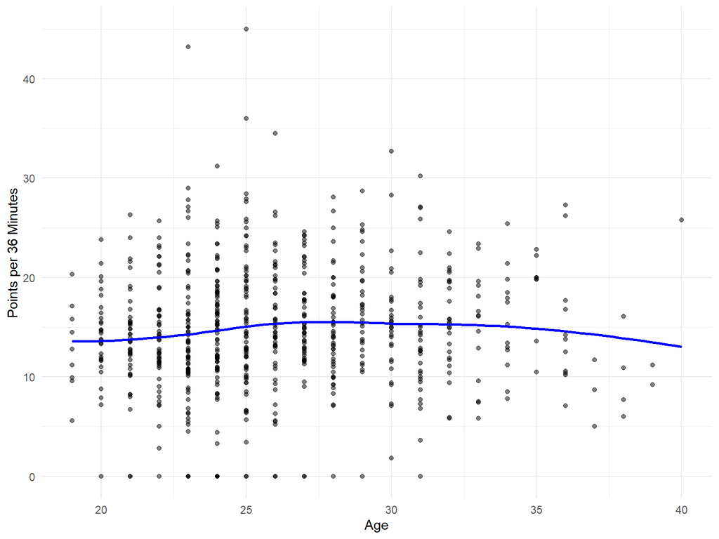

### 3. Scoring Distribution by Age Group

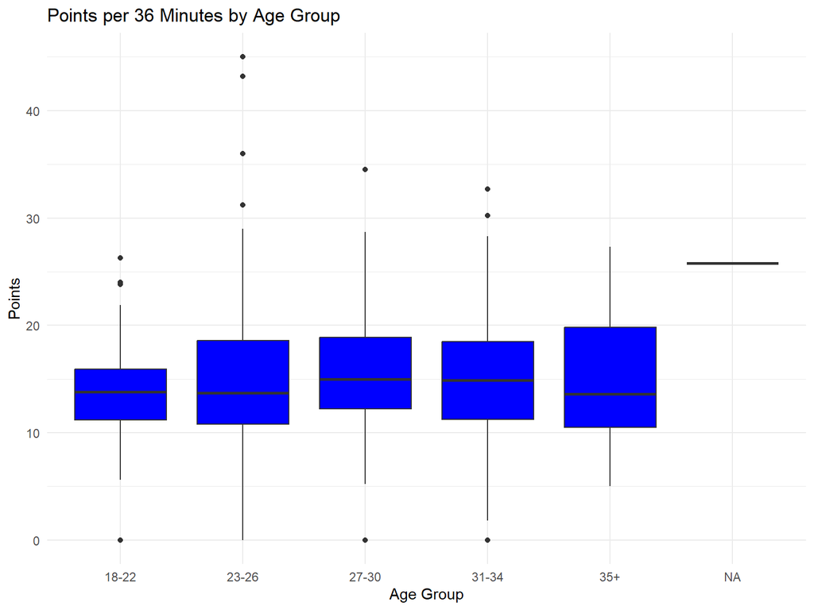

### 4. Peak Performance Age

We identify the age at which players, on average, score the most points per 36 minutes. The table below shows the age with the highest mean scoring output.

```
## # A tibble: 1 × 2
##     Age mean_points
##   <dbl>       <dbl>
## 1    40        25.8
```

Based on the analysis for individual players, we can now conduct data analysis at the team level. Upon reviewing the original dataset, we observe that our NBA dataset includes player-level statistics, such as:

1. Youth (Age): Represented by the “Age” column.
2. Scoring Efficiency: Represented by FG%, 3P%, FT%, or PTS.
3. Defensive Ability: Estimated using STL, BLK, and DRB.

By assigning weights to each of these categories—Youth (40%), Scoring Efficiency (30%), and Defensive Ability (30%)—we can calculate the Potential_Score for each team. This allows us to determine the top 6 teams with the highest potential.

Top 6 NBA Teams by Potential Score

| Team | Age | FG_percent | X3P_percent | FT_percent | PTS | STL | BLK | DRB | Potential_Score |
| --- | --- | --- | --- | --- | --- | --- | --- | --- | --- |
| OKC | 24.526 | 0.449 | 2.058 | 0.656 | 15.947 | 1.316 | 0.821 | 4.947 | 0.693 |
| ATL | 25.650 | 0.482 | 2.285 | 0.744 | 16.825 | 1.275 | 0.790 | 4.680 | 0.678 |
| UTA | 24.650 | 0.455 | 1.910 | 0.750 | 14.620 | 1.210 | 0.660 | 5.000 | 0.658 |
| BRK | 24.364 | 0.421 | 2.355 | 0.675 | 15.609 | 1.091 | 0.559 | 4.441 | 0.632 |
| POR | 23.833 | 0.409 | 1.400 | 0.650 | 13.889 | 1.300 | 0.800 | 4.467 | 0.621 |
| HOU | 25.882 | 0.459 | 1.812 | 0.700 | 16.076 | 1.171 | 1.006 | 4.976 | 0.620 |

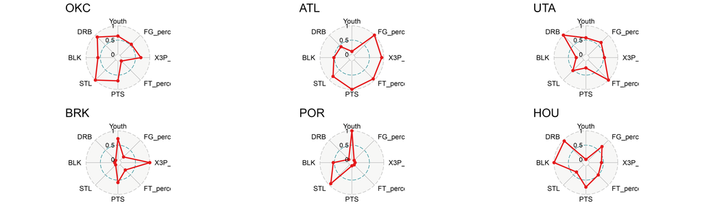

Radar Profiles of Top 6 Teams